# Identificación de genes diferencialmente expresados

# Identificación de genes diferencialmente expresados

Mediante modelos lineales

```r
targets <- read.csv("archivos intermedios/selected targets.csv", sep = ";")
load(file="archivos intermedios/filtrados.Rdata")
nrow(exprs(filtrados))
```

```
[1] 4037
```

Construyo la matriz de diseño y de contraste:

```r
library(limma)
designMat<- model.matrix(~0+group, pData(filtrados))
colnames(designMat) <- c("CB", "cHL", "NLPHL")
designMat
```

```
       CB cHL NLPHL
cHL1    0   1     0
cHL2    0   1     0
cHL3    0   1     0
cHL4    0   1     0
cHL5    0   1     0
cHL6    0   1     0
cHL7    0   1     0
cHL8    0   1     0
cHL9    0   1     0
cHL10   0   1     0
cHL11   0   1     0
cHL12   0   1     0
NLPHL1  0   0     1
NLPHL2  0   0     1
NLPHL3  0   0     1
NLPHL4  0   0     1
NLPHL5  0   0     1
CB1     1   0     0
CB2     1   0     0
CB3     1   0     0
CB4     1   0     0
CB5     1   0     0
attr(,"assign")
[1] 1 1 1
attr(,"contrasts")
attr(,"contrasts")$group
[1] "contr.treatment"
```

```r
cont.matrix <- makeContrasts (CBvscHL = CB - cHL,
                              CBvsNLPHL = CB - NLPHL,
                              cHLvsNLPHL = cHL - NLPHL,
                              levels=designMat)
cont.matrix
```

```
       Contrasts
Levels  CBvscHL CBvsNLPHL cHLvsNLPHL
  CB          1         1          0
  cHL        -1         0          1
  NLPHL       0        -1         -1
```

## Estimación del modelo y selección de genes DGE

```r
# Se ajusta el expresionset a la matriz de diseño
fit<-lmFit(filtrados, designMat)
# se hace el contraste usando la matriz de contraste
fit.main<-contrasts.fit(fit, cont.matrix)
fit.main<-eBayes(fit.main)
class(fit.main)
```

```
[1] "MArrayLM"
attr(,"package")
[1] "limma"
```

```r
CBvscHL <- topTable (fit.main, number=nrow(fit.main), coef="CBvscHL", adjust="fdr")
head(CBvscHL)
```

|  | logFC | AveExpr | t | P.Value | adj.P.Val | B |
| --- | --- | --- | --- | --- | --- | --- |
| 229656_s_at | 7.099291 | 3.856641 | 23.06004 | 3.786936e-20 | 1.528786e-16 | 34.99938 |
| 202252_at | -6.545835 | 7.734384 | -20.96465 | 5.103676e-19 | 1.030177e-15 | 32.70065 |
| 213975_s_at | -7.914406 | 8.365513 | -20.08828 | 1.622565e-18 | 2.183431e-15 | 31.66036 |
| 220059_at | 5.406194 | 4.474885 | 18.11824 | 2.585761e-17 | 2.179663e-14 | 29.13009 |
| 209392_at | -7.236763 | 7.368352 | -18.08893 | 2.699607e-17 | 2.179663e-14 | 29.09030 |
| 210258_at | 7.192853 | 4.433497 | 17.87843 | 3.685254e-17 | 2.479561e-14 | 28.80250 |

```r
nrow(CBvscHL)
```

```
[1] 4037
```

```r
CBvsNLPHL <- topTable (fit.main, number=nrow(fit.main), coef="CBvsNLPHL", adjust="fdr")
head(CBvsNLPHL)
```

|  | logFC | AveExpr | t | P.Value | adj.P.Val | B |
| --- | --- | --- | --- | --- | --- | --- |
| 213975_s_at | -9.034364 | 8.365513 | -19.29926 | 4.775874e-18 | 1.794991e-14 | 30.19760 |
| 229656_s_at | 6.897832 | 3.856641 | 18.85717 | 8.892698e-18 | 1.794991e-14 | 29.65545 |
| 209392_at | -7.917813 | 7.368352 | -16.65684 | 2.388723e-16 | 3.214425e-13 | 26.73010 |
| 202252_at | -5.320435 | 7.734384 | -14.34130 | 1.145601e-14 | 1.156197e-11 | 23.18568 |
| 209395_at | -7.503765 | 6.759732 | -13.78149 | 3.139130e-14 | 2.534534e-11 | 22.24689 |
| 209969_s_at | -5.126040 | 9.086178 | -13.57651 | 4.575484e-14 | 3.056774e-11 | 21.89452 |

```r
nrow(CBvsNLPHL)
```

```
[1] 4037
```

```r
cHLvsNLPHL <- topTable (fit.main, number=nrow(fit.main), coef="cHLvsNLPHL", adjust="fdr")
head(cHLvsNLPHL)
```

|  | logFC | AveExpr | t | P.Value | adj.P.Val | B |
| --- | --- | --- | --- | --- | --- | --- |
| 210258_at | -3.735242 | 4.433497 | -9.284254 | 3.599727e-10 | 1.039896e-06 | 13.17704 |
| 204674_at | -3.377600 | 6.161153 | -8.911876 | 8.731015e-10 | 1.039896e-06 | 12.34661 |
| 220358_at | 3.348399 | 7.109230 | 8.847219 | 1.020202e-09 | 1.039896e-06 | 12.20032 |
| 207861_at | 6.153865 | 7.264160 | 8.843111 | 1.030365e-09 | 1.039896e-06 | 12.19101 |
| 224406_s_at | -3.262745 | 5.555709 | -8.328504 | 3.629413e-09 | 2.930388e-06 | 11.00432 |
| 206914_at | -2.907124 | 3.573113 | -7.961154 | 9.106956e-09 | 6.127464e-06 | 10.13359 |

```r
nrow(cHLvsNLPHL)
```

```
[1] 4037
```

Los rownames son los probeset del microarray, en el siguiente paso se asignarán anotaciones de interés usando esta función propuesta por el profesor:

```r
library(hgu133plus2.db)
annotatedTopTable <- function(topTab)
{
  # saca los rownames a la columna PROBEID
  topTab <- cbind(PROBEID=rownames(topTab), topTab)
  myProbes <- rownames(topTab)
  # de las anotaciones concretas del microarray, elijo estás 3, si quiero otras anotaciones las puedo añadir aquí
  geneAnots <- select(hgu133plus2.db, myProbes, c("SYMBOL", "ENTREZID", "GENENAME"))
  # combino la tabla de anotaciones con las tabla de expresión diferencial
  annotatedTopTab<- merge(x=geneAnots, y=topTab, by="PROBEID")
return(annotatedTopTab)
}
```

```r
anotaciones <- lapply(list(CBvscHL,CBvsNLPHL, cHLvsNLPHL), function(x){annotatedTopTable(x)})
names(anotaciones) <- c("CBvscHL", "CBvsNLPHL", "cHLvsNLPHL")
anotaciones$CBvscHL
```

| PROBEID | SYMBOL | ENTREZID | GENENAME | logFC | AveExpr | t | P.Value | adj.P.Val | B |
| --- | --- | --- | --- | --- | --- | --- | --- | --- | --- |
| 1405_i_at | CCL5 | 6352 | C-C motif chemokine ligand 5 | -5.472194085 | 5.626696 | -11.20658854 | 4.940087e-12 | 2.932813e-10 | 17.525054616 |
| 1552257_a_at | TTLL12 | 23170 | tubulin tyrosine ligase like 12 | -0.557656492 | 4.864409 | -1.54334203 | 1.336356e-01 | 1.615714e-01 | -5.756552364 |
| 1552263_at | MAPK1 | 5594 | mitogen-activated protein kinase 1 | 0.741023120 | 5.290190 | 1.78555181 | 8.467803e-02 | 1.069603e-01 | -5.380026999 |
| 1552287_s_at | AFG3L1P | 172 | AFG3 like matrix AAA peptidase subunit 1, pseudogene | 1.850666314 | 3.939672 | 5.65810051 | 4.142886e-06 | 2.112632e-05 | 4.061355551 |
| 1552309_a_at | NEXN | 91624 | nexilin F-actin binding protein | -0.715466631 | 2.436678 | -1.77510461 | 8.642194e-02 | 1.088226e-01 | -5.397186809 |
| 1552310_at | C15orf40 | 123207 | chromosome 15 open reading frame 40 | 0.366740936 | 3.717778 | 0.79369983 | 4.338434e-01 | 4.711933e-01 | -6.609669749 |
| 1552316_a_at | GIMAP1 | 170575 | GTPase, IMAP family member 1 | -5.789558210 | 6.493417 | -13.99925851 | 2.113233e-14 | 5.018308e-12 | 22.809905581 |
| 1552426_a_at | TM2D3 | 80213 | TM2 domain containing 3 | -0.575718173 | 3.803000 | -1.28068767 | 2.104932e-01 | 2.439039e-01 | -6.111701414 |
| 1552582_at | ABCC13 | 150000 | ATP binding cassette subfamily C member 13 (pseudogene) | 0.569626973 | 4.444582 | 0.92724217 | 3.614855e-01 | 3.994845e-01 | -6.494886763 |
| 1552628_a_at | HERPUD2 | 64224 | HERPUD family member 2 | -0.097809476 | 4.862125 | -0.20491470 | 8.390762e-01 | 8.563622e-01 | -6.907489335 |

[output cut: 990 more lines]

```r
write.csv(anotaciones$CBvscHL, file="00 Resultados/CB vs cHL.csv")
anotaciones$CBvsNLPHL
```

| PROBEID | SYMBOL | ENTREZID | GENENAME | logFC | AveExpr | t | P.Value | adj.P.Val | B |
| --- | --- | --- | --- | --- | --- | --- | --- | --- | --- |
| 1405_i_at | CCL5 | 6352 | C-C motif chemokine ligand 5 | -3.649154966 | 5.626696 | -6.289600787 | 7.350989e-07 | 1.279135e-05 | 5.86535675 |
| 1552257_a_at | TTLL12 | 23170 | tubulin tyrosine ligase like 12 | -1.340508285 | 4.864409 | -3.122365680 | 4.054187e-03 | 1.272687e-02 | -2.47667927 |
| 1552263_at | MAPK1 | 5594 | mitogen-activated protein kinase 1 | 0.945362243 | 5.290190 | 1.917157488 | 6.515836e-02 | 1.138227e-01 | -4.99069390 |
| 1552287_s_at | AFG3L1P | 172 | AFG3 like matrix AAA peptidase subunit 1, pseudogene | 1.274781391 | 3.939672 | 3.280175596 | 2.710276e-03 | 9.057437e-03 | -2.09784770 |
| 1552309_a_at | NEXN | 91624 | nexilin F-actin binding protein | -0.441157285 | 2.436678 | -0.921185013 | 3.645853e-01 | 4.510667e-01 | -6.32837586 |
| 1552310_at | C15orf40 | 123207 | chromosome 15 open reading frame 40 | 0.496261257 | 3.717778 | 0.903911905 | 3.735206e-01 | 4.591664e-01 | -6.34401032 |
| 1552316_a_at | GIMAP1 | 170575 | GTPase, IMAP family member 1 | -5.766467869 | 6.493417 | -11.735141344 | 1.646139e-12 | 4.430308e-10 | 18.50753209 |
| 1552426_a_at | TM2D3 | 80213 | TM2 domain containing 3 | -1.272872905 | 3.803000 | -2.383072044 | 2.396851e-02 | 5.188250e-02 | -4.11218563 |
| 1552582_at | ABCC13 | 150000 | ATP binding cassette subfamily C member 13 (pseudogene) | 0.779127014 | 4.444582 | 1.067406228 | 2.946301e-01 | 3.823278e-01 | -6.18495761 |
| 1552628_a_at | HERPUD2 | 64224 | HERPUD family member 2 | -0.086218051 | 4.862125 | -0.152022973 | 8.802259e-01 | 9.051125e-01 | -6.74340418 |

[output cut: 990 more lines]

```r
write.csv(anotaciones$CBvsNLPHL, file="00 Resultados/CB vs NLPHL.csv")
anotaciones$cHLvsNLPHL
```

| PROBEID | SYMBOL | ENTREZID | GENENAME | logFC | AveExpr | t | P.Value | adj.P.Val | B |
| --- | --- | --- | --- | --- | --- | --- | --- | --- | --- |
| 1405_i_at | CCL5 | 6352 | C-C motif chemokine ligand 5 | 1.823039119 | 5.626696 | 3.733429220 | 8.246749e-04 | 1.513278e-02 | -0.75968291 |
| 1552257_a_at | TTLL12 | 23170 | tubulin tyrosine ligase like 12 | -0.782851793 | 4.864409 | -2.166581213 | 3.865919e-02 | 1.194008e-01 | -4.28325567 |
| 1552263_at | MAPK1 | 5594 | mitogen-activated protein kinase 1 | 0.204339123 | 5.290190 | 0.492370724 | 6.261796e-01 | 7.345729e-01 | -6.35510154 |
| 1552287_s_at | AFG3L1P | 172 | AFG3 like matrix AAA peptidase subunit 1, pseudogene | -0.575884922 | 3.939672 | -1.760671143 | 8.888140e-02 | 1.970424e-01 | -4.99094148 |
| 1552309_a_at | NEXN | 91624 | nexilin F-actin binding protein | 0.274309345 | 2.436678 | 0.680573715 | 5.015615e-01 | 6.323275e-01 | -6.24492937 |
| 1552310_at | C15orf40 | 123207 | chromosome 15 open reading frame 40 | 0.129520321 | 3.717778 | 0.280307557 | 7.812397e-01 | 8.533183e-01 | -6.43743272 |
| 1552316_a_at | GIMAP1 | 170575 | GTPase, IMAP family member 1 | 0.023090341 | 6.493417 | 0.055832870 | 9.558594e-01 | 9.678466e-01 | -6.47550619 |
| 1552426_a_at | TM2D3 | 80213 | TM2 domain containing 3 | -0.697154732 | 3.803000 | -1.550823845 | 1.318343e-01 | 2.529539e-01 | -5.31084051 |
| 1552582_at | ABCC13 | 150000 | ATP binding cassette subfamily C member 13 (pseudogene) | 0.209500040 | 4.444582 | 0.341025411 | 7.355530e-01 | 8.175737e-01 | -6.41843479 |
| 1552628_a_at | HERPUD2 | 64224 | HERPUD family member 2 | 0.011591425 | 4.862125 | 0.024284491 | 9.807927e-01 | 9.863530e-01 | -6.47678332 |

[output cut: 990 more lines]

```r
write.csv(anotaciones$cHLvsNLPHL, file="00 Resultados/cHL vs NLPHL.csv")
save(anotaciones, file = "archivos intermedios/anotaciones.Rdata")
```

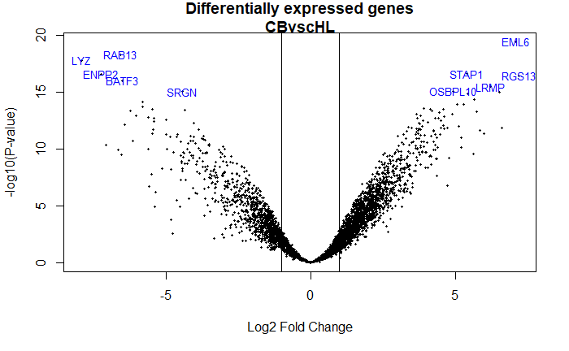

```r
geneSymbols <- select(hgu133plus2.db, rownames(fit.main), c("SYMBOL"))
SYMBOLS<- geneSymbols$SYMBOL
# el parametro highlight es el que marca los genes más diferencialmente expresados.
volcanoplot(fit.main, coef=1, highlight=10, names=SYMBOLS,
            main=paste("Differentially expressed genes",
                       colnames(cont.matrix)[1], sep="\n"))
abline(v=c(-1,1)) # te indica los limites, en mi caso sería (2,-2)
```

# Comparaciones múltiples

Comparaciones dos a dos entre las 3 condiciones.

```r
#Se consideran genes expresados diferencialmente aquellos en los que el fold change >abs(1), p-value ajustado <0.1.
res<-decideTests(fit.main, method="separate", adjust.method="fdr", p.value=0.1, lfc=1)
res # clase TestResults
```

```
TestResults matrix
             Contrasts
              CBvscHL CBvsNLPHL cHLvsNLPHL
  204639_at         1         0         -1
  212607_at        -1        -1          0
  232259_s_at       0         0          0
  207078_at         1         1          0
  228647_at         0         0          0
4032 more rows ...
```

“+1” significa que esta sobreexpresado y “-1” significa subexpresado.

```r
# suma por filas los que son diferentes
sum.res.rows<-apply(abs(res),1,sum)
# selecciona de res los que tienen expresion diferencial entre al menos 1 grupo
res.selected<-res[sum.res.rows!=0,]
# número de genes diferencialmente expresados en al menos una comparación:
nrow(res.selected)
```

```
[1] 3092
```

```r
# resumen de la expresión
summary(res)
```

```
       CBvscHL CBvsNLPHL cHLvsNLPHL
Down      1055      1146        749
NotSig    1358      2058       3203
Up        1624       833         85
```

El número de genes que se consideran diferencialmente expresados en cada condicion se puede representar con un diagrama de venn:

```r
head(res.selected)
```

```
             Contrasts
              CBvscHL CBvsNLPHL cHLvsNLPHL
  204639_at         1         0         -1
  212607_at        -1        -1          0
  207078_at         1         1          0
  209028_s_at       1         1          0
  202382_s_at      -1        -1          0
  227647_at         0        -1          0
```

```r
vennDiagram (res.selected, cex=0.9)
# las condiciones se tienen que haber elegido antes
title("Genes in common between the three comparisons\n Genes selected with FDR < 0.1 and logFC > 1")
```

```r
tiff("00 Resultados/VennPlot.tiff", res = 150, width = 5.5, height = 5.5, units = 'in')
  vennDiagram (res.selected[,1:3], cex=0.9)
```

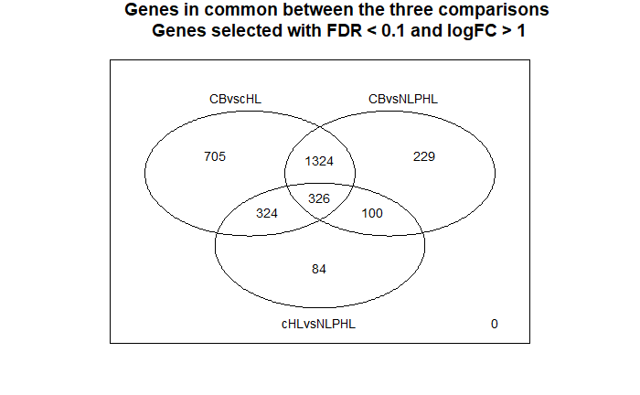

```r
  title("Genes in common between the three comparisons\n Genes selected with FDR < 0.1 and logFC > 1")
dev.off()
```

Comentario: Las celulas sanas (CB) presentan una expresión diferencial respecto a las celulas tumorales de 3008 genes. Respecto al número de genes diferencialmente expresados las celulas CB tiene una expresión más parecida a las NLPHL (con 1979 genes diferentes) que con las cHL (con 2679 genes diferentes). De estos genes diferentes, 1650 son genes diferentes en las dos condiciones, por lo que las cHL tienen en total 700 que las cHL.

Al comparar los dos tipos de celulas tumorales vemos que presentan expresión diferencial en 834 genes.

Parece que las celulas NHLPL tienen unos patrones de expresión más parecidos a los de las celulas sanas que las cHL, en el siguiente apartado se analizarán los niveles de expresión, para apoyar o rechazar esta hipótesis.

Es una forma de visualizar los genes expresados de forma diferencial, preferiblemente ordenandolos para encontrar clusters de patrón comun.

```r
# con estas dos lineas se seleccionan los genes del expresionset que presentan expresión diferencial en la comparación multiple (en al menos 1 comparación)
probesInHeatmap <- rownames(res.selected)
HMdata <- exprs(filtrados)[rownames(exprs(filtrados)) %in% probesInHeatmap,]
# es un filtrado del filtrado que hicimos previamente, seleccionando el 20% de los genes más variables

# se hace una anotación como ya se ha visto anteriormente
geneSymbols <- select(hgu133plus2.db, rownames(HMdata), c("SYMBOL"))
SYMBOLS<- geneSymbols$SYMBOL
rownames(HMdata) <- SYMBOLS
write.csv(HMdata, file = file.path("00 Resultados/data4Heatmap.csv"))
```

representación sin ordenar

```r
my_palette <- colorRampPalette(c("blue", "red"))(n = 299)
library(gplots)
heatmap.2(HMdata,
          Rowv = FALSE, Colv = FALSE,
          main = "Differentially expressed genes \n FDR < 0,1, logFC >=1",
          scale = "row", col = my_palette, sepcolor = "white", sepwidth = c(0.05,0.05), cexRow = 0.5, cexCol = 0.9,
          key = TRUE, keysize = 1.5, density.info = "histogram",
          ColSideColors = c(rep("red",12),rep("yellow",5),rep("cyan",5)),
          tracecol = NULL, dendrogram = "none", srtCol = 30)

tiff("00 Resultados/heatmap no orden.tiff", res = 150, width = 5.5, height = 5.5, units = 'in')
```

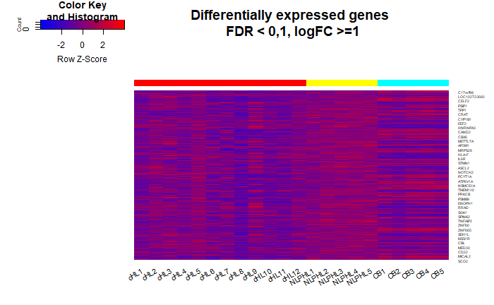

```r
heatmap.2(HMdata,
          Rowv = FALSE, Colv = FALSE,
          main = "Differentially expressed genes \n FDR < 0,1, logFC >=1",
          scale = "row", col = my_palette, sepcolor = "white", sepwidth = c(0.05,0.05), cexRow = 0.5, cexCol = 0.9,
          key = TRUE, keysize = 1.5, density.info = "histogram",
          ColSideColors = c(rep("red",12),rep("yellow",5),rep("cyan",5)),
          tracecol = NULL, dendrogram = "none", srtCol = 30)
dev.off()
```

representación ordenada

```r
heatmap.2(HMdata, Rowv = TRUE, Colv = TRUE, dendrogram = "both", # solo se diferencian estos 3 parámetros
         main = "Differentially expressed genes \n FDR < 0,1, logFC >=1",
          scale = "row", col = my_palette, sepcolor = "white", sepwidth = c(0.05,0.05), cexRow = 0.5, cexCol = 0.9,
          key = TRUE, keysize = 1.5, density.info = "histogram",
          ColSideColors = c(rep("red",12),rep("yellow",5),rep("cyan",5)),
          tracecol = NULL, srtCol = 30)

tiff("00 Resultados/heatmap orden.tiff", res = 150, width = 5.5, height = 5.5, units = 'in')
```

[output not shown]

```r
heatmap.2(HMdata, Rowv = TRUE, Colv = TRUE, dendrogram = "both", # solo se diferencian estos 3 parámetros
         main = "Differentially expressed genes \n FDR < 0,1, logFC >=1",
          scale = "row", col = my_palette, sepcolor = "white", sepwidth = c(0.05,0.05), cexRow = 0.5, cexCol = 0.9,
          key = TRUE, keysize = 1.5, density.info = "histogram",
          ColSideColors = c(rep("red",12),rep("yellow",5),rep("cyan",5)),
          tracecol = NULL, srtCol = 30)
dev.off()
```